# Optimización de funciones escalares diferenciables con `SymPy`

[figure not shown]

- Mediante optimización se obtienen soluciones elegantes tanto en teoría como en ciertas aplicaciones.
- La teoría de optimización usa elementos comenzando con cálculo elemental y álgebra lineal básica, y luego se extiende con análisis funcional y convexo.
- Las aplicaciones en optimización involucran ciencia, ingeniería, economía, finanzas e industria.
- El amplio y creciente uso de la optimización lo hace escencial para estudiantes y profesionales de cualquier rama de la ciencia y la tecnología.

**Referencia:**

- http://www.math.uwaterloo.ca/~hwolkowi//henry/reports/talks.d/t06talks.d/06msribirs.d/optimportance.shtml

[figure not shown]

### Algunas aplicaciones son:

1. **Ingeniería:**
- Encontrar la composición de equilibrio de una mezcla de diferentes átomos.
- Planeación de ruta para un robot (o vehículo aéreo no tripulado).
- Planeación de la mano de obra óptima en una construcción o planta de producción.
- Análisis conformacional - Isomería conformacional en modelado molecular
- Desempeño en fermentación de productos.
- Estimación de parámetros en bioquímica e ingeniería metabólica.
2. **Distribución óptima de recursos:**
- Distribución de rutas de vuelo.
- Encontrar una dieta óptima.
- Planeación de ruta óptima.
3. **Optimización financiera:**
- Administración de riesgos.
- Portafolios de inversión.
- Problema de maximización de la utilidad.
- la calibración de modelos de precios de opciones para datos de mercado
- la optimización de la función de utilidad de un agente

### En esta clase veremos aspectos básicos de optimización. Específicamente, veremos cómo obtener máximos y mínimos de una función escalar de una variable (como en cálculo diferencial).

[figure not shown]

### Criterio de la segunda derivada

Sea $f(x)$ una función tal que $f'(c)=0$ y cuya segunda derivada existe en un intervalo abierto que contiene a $c$.

- Si $f''(c)>0$, entonces $f(c)$ es un mínimo relativo.
- Si $f''(c)<0$, entonces $f(c)$ es un máximo relativo.
- Si $f''(c)=0$, entonces el criterio no decide.

### Metodología

1. Definir el criterio de optimización.
   1. Definiendo una variable simbólica o
   2. desde el entorno `def`.
2. Derivar la función a optimizar.
3. Encontrar la raíz de la derivada.
4. Definir qué puntos son máximos o mínimos.
   1. Usando el criterio de la segunda derivada o
   2. evaluando numéricamente (método gráfico).

### Ejemplo

Encontrar el minimo o maximo en la función $f(x)=(x-2)^2$

```python
# Librerías necesarias
import sympy as sym
import numpy as np
from IPython.display import display, Markdown
```

```python
# Paso 1. Definimos el criterio de optimización.
#
x = sym.var('x') # Definimos la variable con respecto a la cual optimizaremos
f=(x-2)**2   # Inciso A. Definiendo una variable simbólica

# Paso 2. Derivar la función a optimizar.
df=sym.diff(f,x) # Derivamos 'f' con respecto a 'x' (si existe una sola vareiable simbólica, ésta se puede omitir)
print("Derivada con respecto a x:")
display(df)
```

```
Derivada con respecto a x:
```

$\displaystyle 2 x - 4$

```python
# Paso 3. Encontrar la raíz de la derivada.
x0=sym.solve(df,x)[0] # (También se puede omitir la variable simólica)
display(Markdown(f"Encontrar el valor de x0: {x0}"))
```

Encontrar el valor de x0: 2

```python
# Paso 4. Definir qué puntos son máximos o mínimos.
d2f=sym.diff(df) # Inciso A. Usando el criterio de la segunda derivada (derivando la primer derivada).
d2f
```

$\displaystyle 2$

El 2 es positivo, por tanto es un minimo.

```python
f=(x-2)**2
sym.diff(f,x,2) # (Derivando la función dos veces)
#sym.diff(f,x,x) # Es lo mismo
```

$\displaystyle 2$

**Conclusión:**

Encontramos un mínimo global en $x=2$ para $f(x)=(x-2)^2$, donde $f(x)|_{x=2}=0$.

### Ejemplo Visualización

```python
# Instalación de dependencias
#%pip install ipywidgets
#%pip install matplotlib
```

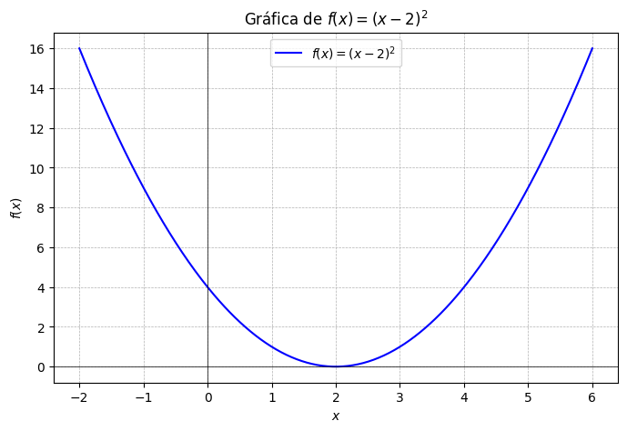

```python
import numpy as np
import matplotlib.pyplot as plt

# Definir la función
def f(x):
    return (x - 2) ** 2

# Crear valores de x
x = np.linspace(-2, 6, 400)
y = f(x)

# Graficar la función
plt.figure(figsize=(8, 5))
plt.plot(x, y, label=r"$f(x) = (x-2)^2$", color="blue")
plt.axhline(0, color="black", linewidth=0.5)
plt.axvline(0, color="black", linewidth=0.5)
plt.grid(True, linestyle="--", linewidth=0.5)
plt.title("Gráfica de $f(x) = (x-2)^2$")
plt.xlabel("$x$")
plt.ylabel("$f(x)$")
plt.legend()
plt.show()
```

### Ejemplo

Considere $g(x)=(x-2)^3$.

- Usando `sympy`, muestre que $g'(2)=0$.
- Sin embargo, descartar que $x=2$ es un extremo de $g(x)$ viendo su **gráfica**.

```python
x=sym.var('x')   # Definimos la variable simbólica
g=(x-2)**3       # Definimos la función
dg=sym.diff(g,x) # Derivamos
x0=sym.solve(dg)[0]  # Encontramos las raíces de la derivada
x0
```

$\displaystyle 2$

```python
d2g=sym.diff(dg) # Segunda derivada
d2g
```

$\displaystyle 6 x - 12$

```python
d2g.subs(x,x0) # Evaluamos 'x' en el primer punto crítico
```

$\displaystyle 0$

Como la segunda derivada evaluada en el punto crítico es cero, este criterio no es concluyente, así que usamos el método gráfico. (Analizar la concavidad con la primera derivada)

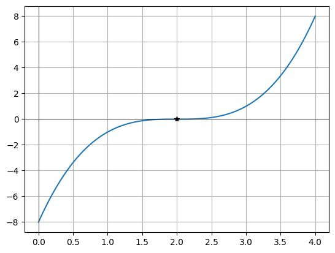

```python
x=sym.var('x')
# Retomando la función
g=(x-2)**3
g_num=sym.lambdify(x,g,'numpy') # Convertimos 'g' simbólica a numérica compatible con numpy
# Graficamos
x_num=np.linspace(0,4,100)      # Graficamos en un rango de 0 a 4 con 100 valores
plt.plot(x_num,g_num(x_num))
plt.plot(x0,g_num(x0),'*k')
plt.axhline(0, color='black', linewidth=0.5)
plt.axvline(0, color='black', linewidth=0.5)
plt.grid()
plt.show()
```

```python
# Usando el entorno 'def'
def g(x):
  return (x-2)**3
```

```python
g(x) # El resultado es numérico
```

$\displaystyle \left(x - 2\right)^{3}$

```python
g(0)
```

```
-8
```

```python
dg=sym.diff(g(x),x) # Ahora el primer argumento es 'g(x)' y no solo 'g'
c=sym.solve(dg)
c
```

```
[2]
```

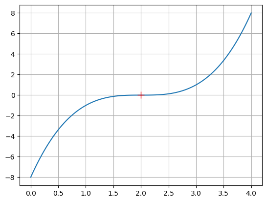

```python
# Graficación
plt.plot(x_num,g(x_num))
plt.plot(c[0],g(c[0]),'+r',ms=10) # ms  ->  marksize
plt.grid()
```

### Ejemplo

¿Qué pasa con $h(x)=(x-2)^4$ al intentar utilizar el criterio de la segunda derivada?.

```python
x=sym.var('x')
def h(x):
  return (x-2)**4
dh=sym.diff(h(x),x)
ddh=sym.diff(dh,x)
c=sym.solve(dh)
ddh.subs(x,c[0])
```

$\displaystyle 0$

Como el criterio de la segunda derivada no concluye, graficamos:

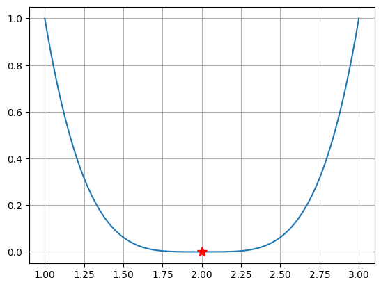

```python
x_num=np.linspace(1,3,500)
plt.plot(x_num,h(x_num))
plt.plot(c[0],h(c[0]),'*r',ms=10)
plt.grid()
```

```python
c[0],h(c[0]) # Punto crítico
```

```
(2, 0)
```

Vemos que el punto crítico $(2,0)$ es un mínimo global para $h(x)=(x-2)^4$.

### Ejemplo

Determinar los extremos absolutos de $f(x)=x^2-2x+5$ en $\left[0,3\right]$.

Obtenemos los puntos críticos de $f$ en $\left[0,3\right]$:

```python
def f(x):
  return x**2-2*x+5
f(x)
```

$\displaystyle x^{2} - 2 x + 5$

```python
df=sym.diff(f(x),x)
c=sym.solve(df)
c
```

```
[1]
```

```python
# Evaluamos en los extremos y en el punto crítico
x=np.array([0,c[0],3])
x
```

```
array([0, 1, 3], dtype=object)
```

```python
f(x)
```

```
array([5, 4, 8], dtype=object)
```

### Conclusión

Vemos que la evaluación del punto crítico $x=1$ en la función $f(x)=x^2-2x+5$, es la menor de las evaluaciónes, por lo que éste se trata de un mínimo.

### Actividad

Determinar los valores extremos absolutos de $f(x) = (x-3)^2(x+3)^2$ en el intervalo $[1,\,4]$, usando `sympy`. Mostrar en una gráfica.

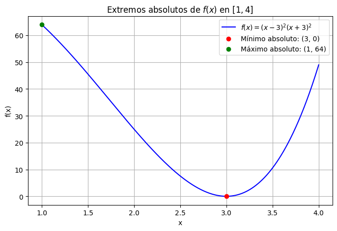

```
Mínimo absoluto: x = 3, f(x) = 0
Máximo absoluto: x = 1, f(x) = 64
```

```python
import sympy as sp
import numpy as np
import matplotlib.pyplot as plt

# Definir la variable y la función
x = sp.symbols('x')
f = (x - 3)**2 * (x + 3)**2

# Calcular la derivada
f_prime = sp.diff(f, x)

# Encontrar los puntos críticos resolviendo f'(x) = 0
critical_points = sp.solve(f_prime, x)

# Filtrar los puntos críticos dentro del intervalo [1,4]
critical_points = [p for p in critical_points if p.is_real and 1 <= p <= 4]

# Evaluar la función en los puntos críticos y en los extremos del intervalo
eval_points = [1, 4] + critical_points
eval_values = [f.subs(x, p) for p in eval_points]

# Encontrar el mínimo y máximo absolutos
min_value = min(eval_values)
max_value = max(eval_values)
min_point = eval_points[eval_values.index(min_value)]
max_point = eval_points[eval_values.index(max_value)]

# Graficar la función en el intervalo [1,4]
X = np.linspace(1, 4, 400)
Y = [f.subs(x, val) for val in X]

plt.figure(figsize=(8, 5))
plt.plot(X, Y, label=r'$f(x) = (x-3)^2(x+3)^2$', color='blue')
plt.scatter([min_point], [min_value], color='red', label=f'Mínimo absoluto: ({min_point}, {min_value})', zorder=3)
plt.scatter([max_point], [max_value], color='green', label=f'Máximo absoluto: ({max_point}, {max_value})', zorder=3)
plt.xlabel("x")
plt.ylabel("f(x)")
plt.title("Extremos absolutos de $f(x)$ en $[1,4]$")
plt.legend()
plt.grid(True)
plt.show()

# Imprimir los resultados
print(f"Mínimo absoluto: x = {min_point}, f(x) = {min_value}")
print(f"Máximo absoluto: x = {max_point}, f(x) = {max_value}")
```

1. **Resistencia de una viga** Una viga de madera tiene una sección transversal rectangular de altura $h$ y ancho $w$. La resistencia $S$ de la viga es directamente proporcional al ancho y al cuadrado de su altura ($S=kwh^2$, donde $k$ es una constante de proporcionalidad). ¿Cuáles son las dimensiones de la viga más fuerte que puede cortarse a partir de un leño redondo de $24$ pulgadas de diámetro?

### Actividad

Realiza el siguiente problema en tu cuaderno y comenta en el codigo para qué sirve cada cosa.

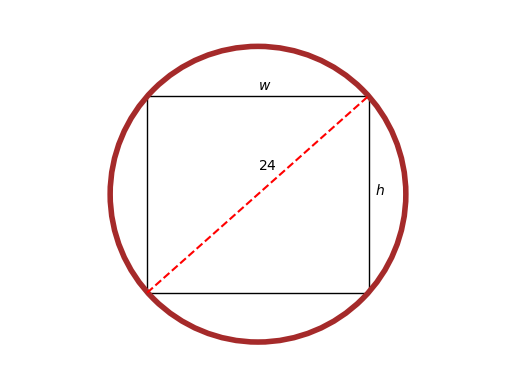

```python
#@markdown
import numpy as np
import matplotlib.pyplot as plt
import matplotlib.patches as patches

C = patches.Circle((0, 0),12, fill=False,color='brown',lw=4) #Se crea un círculo de radio 12, centrado en (0,0)
S = patches.Rectangle((-9,-8),18,16,fill=False,color='k') #Se crea un rectángulo en (0,0) con ancho 18 y altura 16
ax = plt.gca() #Se obtiene el eje de la figura
ax.add_artist(S) #Añadimos el rectángulo a la gráfica
ax.add_artist(C) #Añadimos el círculo a la gráfica

plt.text(0,8.5,'$w$') #Etiqueta para el ancho
plt.text(9.5,0,'$h$') #Etiqueta para la altura

plt.plot([-9,9],[-8,8],'r--') #Dibujar línea punteada en diagonal dentro del círculo
plt.text(0,2,'$24$') #Se etiqueta la diagonal

plt.axis('equal') #Ajustar los ejes
plt.ylim([-15,15]) #Limites del eje y
plt.axis('off') #Ocultar los ejes
plt.show() #Mostrar la figura
```

**Solución:**

Se desea maximizar la resistencia de una viga $$ \mathrm{max}S=kwh^2 $$ donde, usando el teorema de Pitágoras se ve que la altura está en función del diámetro y del ancho, esto es, $h^2=24^2-w^2$; sustituyendo en la resistencia, se tiene $$ \mathrm{max}_{w}S(w)=\mathrm{max}_{w}kw(24^2-w^2), $$ para $0\leq w\leq24$ in.

```python
import sympy as sym
```

```python
w=sym.var('w',real=True,positive=True)
def S(w):
  k=10000     # Constante de resistencia (N/mm^2)
  k=k*25.24**-2 # N/in^2
  return k*w*(24**2-w**2)

dS=sym.diff(S(w),w)
c=sym.solve(dS)
c
```

```
[13.8564064605510]
```

```python
8*sym.sqrt(3).evalf()
```

$\displaystyle 13.856406460551$

```python
ddS=dS.diff(w)   # Segunda derivada
ddS.subs(w,c[0]) # Evaluación del punto crítico
```

$\displaystyle -1305.03801796425$

```python
high=sym.sqrt(24**2-8**2*3) # Altura asociada al ancho óptimo
high
```

$\displaystyle 8 \sqrt{6}$

```python
# Resistencia máxima
S(8*sym.sqrt(3))
```

$\displaystyle 48221.6992623587 \sqrt{3}$

**Respuesta del aluno:**

Encontramos una resistencia máxima en $w=$ 8x(raiz de 3) y $h=$ 8x(raiz de 6), siendo ésta de $S=48.2\sqrt{3}$kN/in.

2. **Iluminación** Una fuente luminosa se localiza sobre el centro de una mesa circular de $4 pies$ de diámetro. Encontrar la altura $h$ de la fuente luminosa de modo tal que la iluminación $I$ en el perímetro de la mesa sea máxima si $I=k(\sin \alpha)/s^2$, donde $s$ es la altura oblicua, $\alpha$ es el ángulo al cual la luz incide sobre la mesa y $k$ es una constante (El valor de esta última constante es irrelevante para el problema, ya que no se pide el valor de la iluminación).

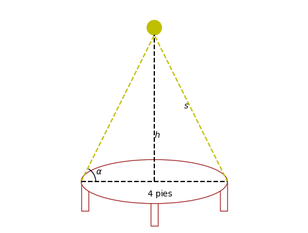

```python
#@markdown
E = patches.Ellipse((0, 0),10, 3,fc='white',ec='brown')
C = patches.Circle((0,10.5),0.5,color='y')
a = patches.Arc((-5,0),2,2,theta2=60)
p1 = patches.Rectangle((-5, -2),0.5, 2, fill=False,color='brown')
p2 = patches.Rectangle((4.5, -2),0.5, 2, fill=False,color='brown')
p3 = patches.Rectangle((-0.25, -3),0.5, 2, fill=False,color='brown')
ax = plt.gca()
ax.add_artist(p1)
ax.add_artist(p2)
ax.add_artist(p3)
ax.add_artist(E)
ax.add_artist(C)
ax.add_artist(a)

plt.text(2,5,'$s$')
plt.text(0,3,'$h$')
plt.text(-4,0.5,r'$\alpha$')
plt.text(-0.5,-1,'$4$ pies')

plt.plot([-5,0,5],[0,10,0],'y--')
plt.plot([-5,5],[0,0],'k--')
plt.plot([0,0],[0,10],'k--')


plt.axis('equal')
plt.ylim([-3.1,12])
plt.axis('off')
plt.show()
```

**Solución:**

Se desea maximizar la iluminación $$ \mathrm{max}I=\mathrm{max}k\frac{\sin(\alpha)}{s^2}, $$ donde, usando el teorema de Pitágoras, se tiene que $s^2=h^2+2^2$, siendo $2$ el radio de la mesa; además, por definición de funciones trigonométricas, sabemos que $\sin(\alpha)=\frac{h}{s}$. Sustituyendo en el criterio de optimización resulta $$ I=k\frac{h/s}{h^2+4}, $$ reemplazando, de nuevo, $s=\sqrt{h^2+4}$, tenemos la iluminación en función de la altura: $$ \mathrm{max}_hI(h)=\mathrm{max}_hk\frac{h}{(h^2+4)^{3/2}}, $$ para $h\geq0$.

```python
import sympy as sp

# Definimos las variables
h = sp.Symbol('h', real=True, positive=True)
R = 2  # Radio de la mesa (4 pies de diámetro)

# La altura oblicua s
s = sp.sqrt(h**2 + R**2)

# Función de iluminación I en función de h
I = h / (s**3)

# Derivada de I respecto a h
dI_dh = sp.simplify(sp.diff(I, h))

# Resolviendo la ecuación dI/dh = 0 para encontrar el valor crítico de h
critical_h = sp.solve(dI_dh, h)

# Filtramos la solución positiva
valid_h = [sol.evalf() for sol in critical_h if sol.is_real and sol > 0]

print(f"Soluciones críticas de h: {critical_h}")

# Mostramos la solución
print(f"Altura válida para máxima iluminación: {valid_h}")
```

```
Soluciones críticas de h: [sqrt(2)]
Altura válida para máxima iluminación: [1.41421356237310]
```

**Respuesta del alumno:**

3. **Fuerza mínima** Se diseña un componente para deslizar un bloque de acero con peso $W=10 N$ a través de una mesa y sobre una canaleta. Se opone al movimiento del bloque una fuerza de fricción proporcional a su peso aparente (sea $k=0.1$ la constante de proporcionalidad). Determinar la fuerza mínima $f$ necesaria para deslizar el bloque y encontrar el valor correspondiente de $\theta$.

Ayudín: $f\cos \theta$ es la fuerza de dirección del movimiento, y $f\sin\theta$ es la fuerza que tiende a levantar el bloque. De tal modo, el peso aparente del bloque es $W-f\sin\theta$.

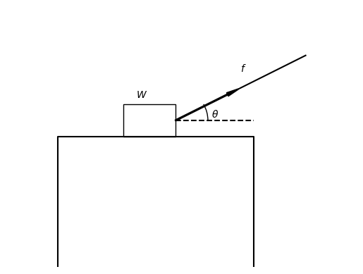

```python
#@markdown
W = patches.Rectangle((0, 2),0.8, 0.5, fill=False,color='k')
a = patches.Arrow(0.8,2.25,1,0.5,width=0.1,color='k')
arc = patches.Arc((0.8,2.25),1,1,theta2=30)
ax = plt.gca()
ax.add_artist(W)
ax.add_artist(a)
ax.add_artist(arc)

plt.text(0.2,2.6,'$W$')
plt.text(1.8,3,'$f$')
plt.text(1.35,2.305,r'$\theta$')

plt.plot([1.8,2.8],[2.75,3.25],'k')
plt.plot([0.8,2],[2.25,2.25],'k--')
plt.plot([-1,-1,2,2],[0,2,2,0],'k')


plt.axis('equal')
plt.ylim([0,4])
plt.axis('off')
plt.show()
```

**Solución:**

Equlibrando las fuerzas horizontales, es fácil ver que, $$ f\cos(\theta)=k(W-f\sin(\theta), $$ donde, el lado izquierdo de la igualdad corresponde a la componente horizontal de la fuerza empleada y el lado derecho, corresponde a la fricción generada.